# Explore_bikeshare_data

### Explore Bike Share Data

For this project, your goal is to ask and answer three questions about the available bikeshare data from Washington, Chicago, and New York. This notebook can be submitted directly through the workspace when you are confident in your results.

You will be graded against the project [Rubric](https://review.udacity.com/#!/rubrics/2508/view) by a mentor after you have submitted. To get you started, you can use the template below, but feel free to be creative in your solutions!

```r
ny <- read.csv('new_york_city.csv')
wash <- read.csv('washington.csv')
chi <- read.csv('chicago.csv')
```

```r
head(ny)
```

| X | Start.Time | End.Time | Trip.Duration | Start.Station | End.Station | User.Type | Gender | Birth.Year |
| --- | --- | --- | --- | --- | --- | --- | --- | --- |
| 5688089 | 2017-06-11 14:55:05 | 2017-06-11 15:08:21 | 795 | Suffolk St & Stanton St | W Broadway & Spring St | Subscriber | Male | 1998 |
| 4096714 | 2017-05-11 15:30:11 | 2017-05-11 15:41:43 | 692 | Lexington Ave & E 63 St | 1 Ave & E 78 St | Subscriber | Male | 1981 |
| 2173887 | 2017-03-29 13:26:26 | 2017-03-29 13:48:31 | 1325 | 1 Pl & Clinton St | Henry St & Degraw St | Subscriber | Male | 1987 |
| 3945638 | 2017-05-08 19:47:18 | 2017-05-08 19:59:01 | 703 | Barrow St & Hudson St | W 20 St & 8 Ave | Subscriber | Female | 1986 |
| 6208972 | 2017-06-21 07:49:16 | 2017-06-21 07:54:46 | 329 | 1 Ave & E 44 St | E 53 St & 3 Ave | Subscriber | Male | 1992 |
| 1285652 | 2017-02-22 18:55:24 | 2017-02-22 19:12:03 | 998 | State St & Smith St | Bond St & Fulton St | Subscriber | Male | 1986 |

```r
head(wash)
```

| X | Start.Time | End.Time | Trip.Duration | Start.Station | End.Station | User.Type |
| --- | --- | --- | --- | --- | --- | --- |
| 1621326 | 2017-06-21 08:36:34 | 2017-06-21 08:44:43 | 489.066 | 14th & Belmont St NW | 15th & K St NW | Subscriber |
| 482740 | 2017-03-11 10:40:00 | 2017-03-11 10:46:00 | 402.549 | Yuma St & Tenley Circle NW | Connecticut Ave & Yuma St NW | Subscriber |
| 1330037 | 2017-05-30 01:02:59 | 2017-05-30 01:13:37 | 637.251 | 17th St & Massachusetts Ave NW | 5th & K St NW | Subscriber |
| 665458 | 2017-04-02 07:48:35 | 2017-04-02 08:19:03 | 1827.341 | Constitution Ave & 2nd St NW/DOL | M St & Pennsylvania Ave NW | Customer |
| 1481135 | 2017-06-10 08:36:28 | 2017-06-10 09:02:17 | 1549.427 | Henry Bacon Dr & Lincoln Memorial Circle NW | Maine Ave & 7th St SW | Subscriber |
| 1148202 | 2017-05-14 07:18:18 | 2017-05-14 07:24:56 | 398.000 | 1st & K St SE | Eastern Market Metro / Pennsylvania Ave & 7th St SE | Subscriber |

```r
head(chi)
```

| X | Start.Time | End.Time | Trip.Duration | Start.Station | End.Station | User.Type | Gender | Birth.Year |
| --- | --- | --- | --- | --- | --- | --- | --- | --- |
| 1423854 | 2017-06-23 15:09:32 | 2017-06-23 15:14:53 | 321 | Wood St & Hubbard St | Damen Ave & Chicago Ave | Subscriber | Male | 1992 |
| 955915 | 2017-05-25 18:19:03 | 2017-05-25 18:45:53 | 1610 | Theater on the Lake | Sheffield Ave & Waveland Ave | Subscriber | Female | 1992 |
| 9031 | 2017-01-04 08:27:49 | 2017-01-04 08:34:45 | 416 | May St & Taylor St | Wood St & Taylor St | Subscriber | Male | 1981 |
| 304487 | 2017-03-06 13:49:38 | 2017-03-06 13:55:28 | 350 | Christiana Ave & Lawrence Ave | St. Louis Ave & Balmoral Ave | Subscriber | Male | 1986 |
| 45207 | 2017-01-17 14:53:07 | 2017-01-17 15:02:01 | 534 | Clark St & Randolph St | Desplaines St & Jackson Blvd | Subscriber | Male | 1975 |
| 1473887 | 2017-06-26 09:01:20 | 2017-06-26 09:11:06 | 586 | Clinton St & Washington Blvd | Canal St & Taylor St | Subscriber | Male | 1990 |

### Question 1

**What is the most common month?**

```r
#the code goes here


#this calculates the mode for each month
mode_month <- function(months){
    uniqm<- unique(months)
    uniqm[which.max(tabulate(match(months,uniqm)))]
}

cities<- list(ny, wash, chi)
for (CITY in cities){
    #extract month from Start.Time
    CITY$month = format(as.Date(CITY$Start.Time, format = '%Y-%m-%d %H:%M:%S'), '%b')
    #print data for each month
    print(aggregate(CITY$month, by=list(CITY$month), FUN=length))
    #print the most common month
    print(mode_month(CITY$month))
}
```

```
  Group.1     x
1     Apr 10661
2     Feb  6364
3     Jan  5745
4     Jun 14000
5     Mar  5820
6     May 12180
[1] "Jun"
  Group.1     x
1     Apr 18522
2     Feb 11563
3     Jan  8946
4     Jun 20335
5     Mar 12612
6     May 17072
[1] "Jun"
  Group.1    x
1     Apr 1526
2     Feb  930
3     Jan  650
4     Jun 2816
5     Mar  803
6     May 1905
[1] "Jun"
```

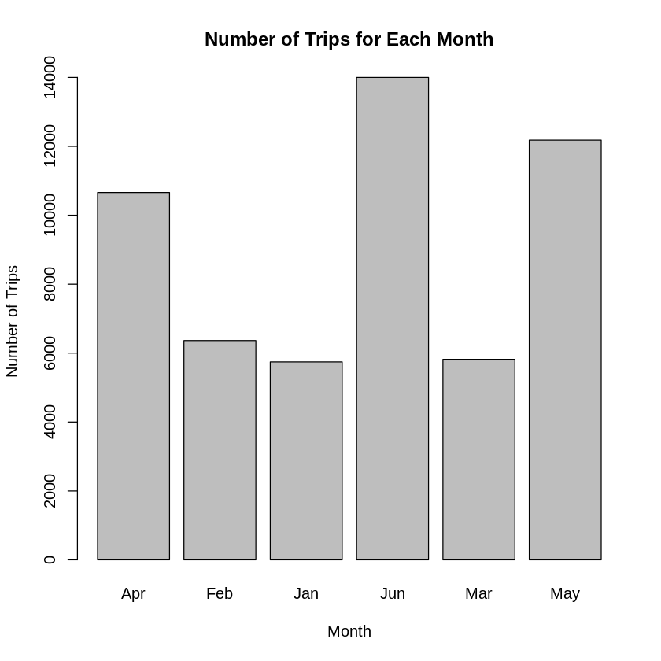

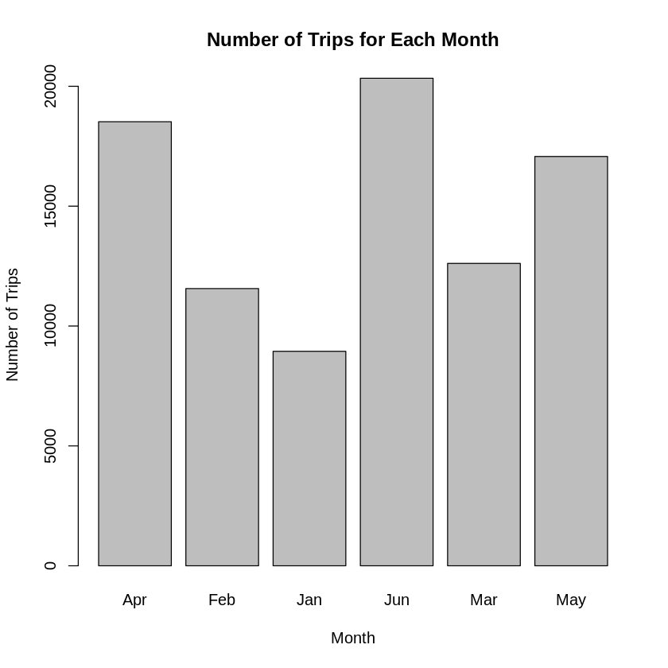

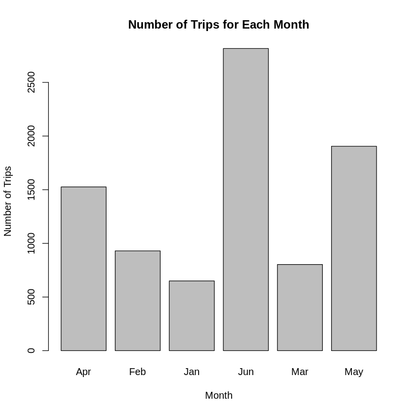

```r
#https://knowledge.udacity.com/questions/557564
library(ggplot2)
cities<- list(ny, wash, chi)
for (CITY in cities){
    #extract month from Start.Time
    CITY$month = format(as.Date(CITY$Start.Time, format = '%Y-%m-%d %H:%M:%S'), '%b')
    #print data for each month
    plot_feature <- aggregate(CITY$month, by=list(CITY$month), FUN=length)
    #print the graph
    barplot(with(plot_feature, setNames(x, Group.1)), main = 'Number of Trips for Each Month', xlab = 'Month', ylab = 'Number of Trips') +
    geom_line(stat = 'count', fun.y = 'mean')
    #stat_summary(geom = 'line', fun.y = 'mean', mapping = aes(x = CITY$month, y = 'Number of Trips'))

}

#files <- list(ny, wash, chi)
#for (file in files){
#    ggplot(aes(x = month), data = file) + geom_bar()
#}
```

```r
'''
                                                References
"Dates" (n.d.). Udacity. Retrieved April 28, 2021 from https://knowledge.udacity.com/questions/158153
"Loop" (n.d.). Udacity. Retrieved April 28, 2021 from https://knowledge.udacity.com/questions/261921
"Mode Month" (n.d.). Udacity. Retrieved April 28, 2021 from https://knowledge.udacity.com/questions/178113
"Print Statement" (2021, April 5). Udacity. Retrieved April 28, 2021 from https://knowledge.udacity.com/questions/555803

'''
```

[output not shown]

**The most common month for all three cities is June. I got this using uniqm.**

### Question 2

**What is the most common start station?**

```r
#https://classroom.udacity.com/nanodegrees/nd118/parts/b6a20e57-d477-45c8-9deb-5b87abe46bb3/modules/675e95c9-472d-457b-b0c2-0a4ff3f8510b/lessons/cf989766-615b-48fc-b448-2fffeaccd072/concepts/32a5db94-1059-4e99-87ad-329e3f7a60df
mode_start_station <- function(start_station){
    uniqm<- unique(start_station)
    uniqm[which.max(tabulate(match(start_station,uniqm)))]
}
cities<- list(ny, wash, chi)
for (CITY in cities){
    #print data for each month
    #plot_feature <- aggregate(CITY$Start.Station, by=list(CITY$Start.Station), FUN=length)
    #find the most common start station
    print(mode_start_station(CITY$Start.Station))
}
```

```
[1] Pershing Square North
636 Levels:  1 Ave & E 16 St 1 Ave & E 18 St 1 Ave & E 30 St ... York St & Jay St
[1] Columbus Circle / Union Station
478 Levels:  10th & E St NW 10th & Florida Ave NW ... Yuma St & Tenley Circle NW
[1] Streeter Dr & Grand Ave
472 Levels: 2112 W Peterson Ave 63rd St Beach ... Woodlawn Ave & Lake Park Ave
```

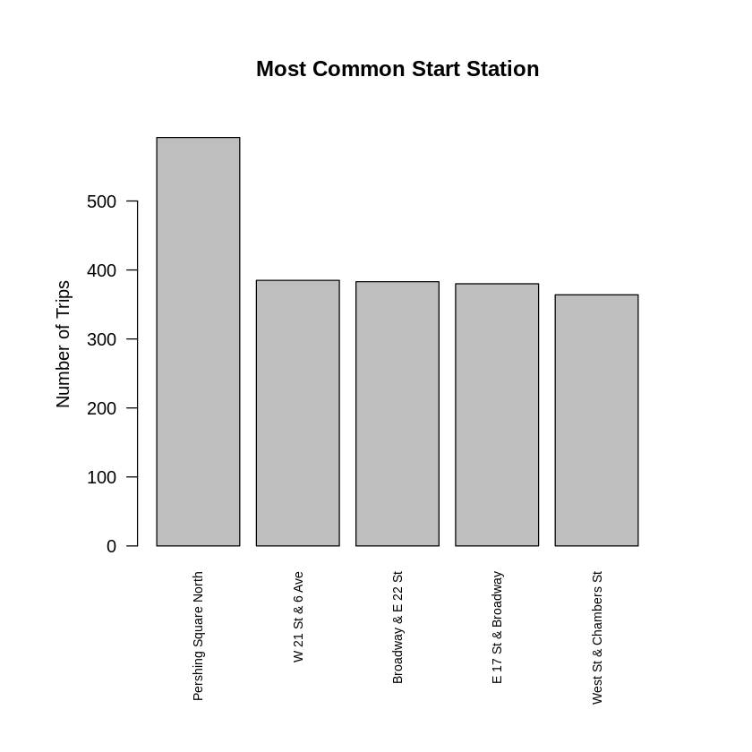

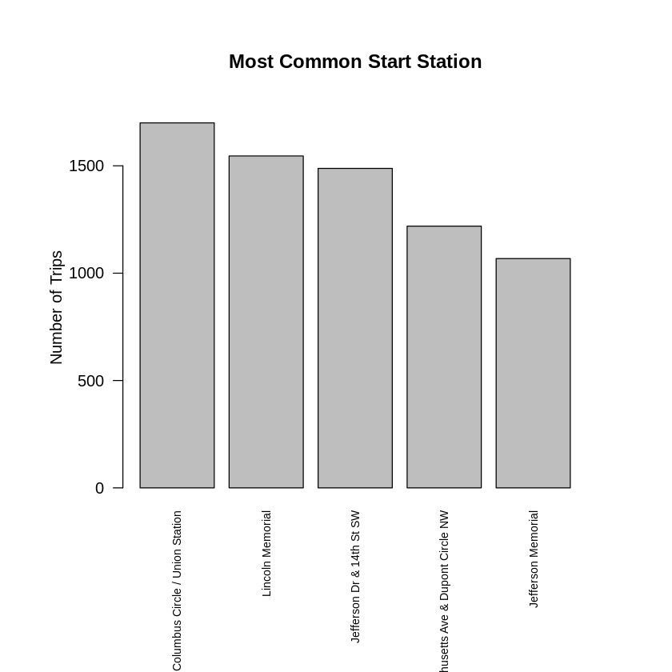

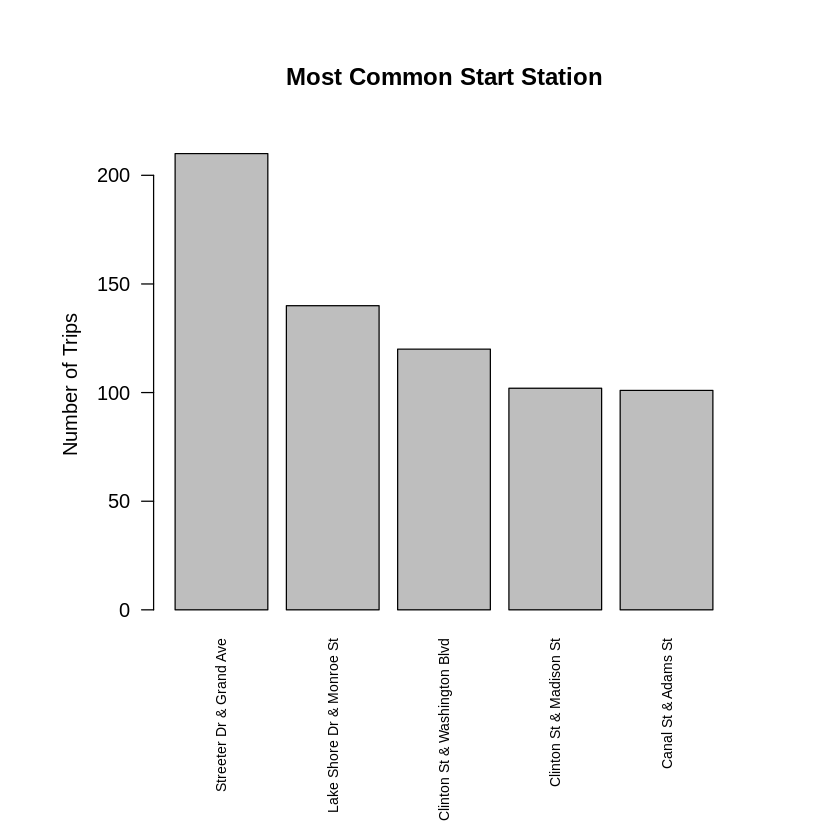

```r
for (CITY in cities){
    #print data for each month
    #plot_feature <- data[order(CITY$Start.Station, decreasing = TRUE), ]
    #plot_feature <- Reduce(rbind, by(plot_feature, plot_feature["group"], head, n=3))
    #plot_feature <- aggregate(CITY$Start.Station, by=list(CITY$Start.Station), FUN=length)
    #barplot(with(plot_feature, setNames(x, Group.1)), main = 'Most Common Start Station', xlab = 'Station', ylab = 'Number of Trips')
    #barplot(with(mode_start_station(CITY$Start.Station), setNames(x, Group.1)), main = 'Most Common Start Station', xlab = 'Station', ylab = 'Number of Trips')
    par(mar = c(7, 4, 4, 2) + 2.4)
    barplot(head(summary(CITY$Start.Station),5), main = 'Most Common Start Station', ylab = 'Number of Trips', las = 2, cex.names=.7) +
    geom_line(stat = 'count', fun.y = 'mean')
    #axis(1, labels = FALSE)
    #labels <- paste("Label")
    #print(head(summary(CITY$Start.Station), 5))
}
#head(summary(chi$Start.Station), 5)
```

```r
'''
                                                        References
"Graph the mode of the stations for each city using rbind?" (2021, May 5). Udacity. Retrieved May 5, 2021 from https://knowledge.udacity.com/questions/571240
"How Can I Create Rotated Axis Labels" (n.d.). Cran-R-Project. Retrieved May 5, 2021 from https://cran.r-project.org/doc/FAQ/R-FAQ.html#How-can-I-create-rotated-axis-labels_003f
"How To Display All X-labels in R Barplot" (n.d.). Stack Overflow. Retrieved May 5, 2021 from https://stackoverflow.com/questions/9981929/how-to-display-all-x-labels-in-r-barplot
"Mode Start Station" (n.d.). Udacity. Retrieved May 5, 2021 from https://classroom.udacity.com/nanodegrees/nd118/parts/b6a20e57-d477-45c8-9deb-5b87abe46bb3/modules/675e95c9-472d-457b-b0c2-0a4ff3f8510b/lessons/cf989766-615b-48fc-b448-2fffeaccd072/concepts/32a5db94-1059-4e99-87ad-329e3f7a60df
"Rotating-X-Axis-Labels-in-R-for-Barplot" (n.d.). Stack Overflow. Retrieved May 5, 2021 from https://stackoverflow.com/questions/10286473/rotating-x-axis-labels-in-r-for-barplot/21978596

'''
```

[output not shown]

### Question 3

**What is the total travel time for users in different cities?**

```r
# Your solution code goes here

total_travel_time <- c()
cities<- list(ny, wash, chi)
#prints total travel time for each city
for (CITY in cities){
    list_item <-sum(CITY$Trip.Duration, na.rm = TRUE)
    print(list_item)
    total_travel_time <- append(total_travel_time, list_item)
}

for (CITY in cities){
    #cat(" Qty of Subscribers is", length(which(CITY['User.Type']=='Subscriber')))
    #cat(" Qty of Customers is", length(which(CITY['User.Type']=='Customer')),'\n')
    #cat("total travel time for subscribers is", sum(CITY['Trip.Duration'], na.rm = TRUE, which(CITY['User.Type']=='Subscriber'), "for CITY\n"))
    print(aggregate(x = CITY$Trip.Duration, by = list(CITY$User.Type), FUN = sum))
}
```

```
[1] 49490073
[1] 109883545
[1] 8087801
     Group.1        x
1                  NA
2   Customer 12189116
3 Subscriber 37084015
     Group.1        x
1                  NA
2   Customer 61777358
3 Subscriber 48106186
     Group.1       x
1               3020
2   Customer 3369740
3 Subscriber 4715041
```

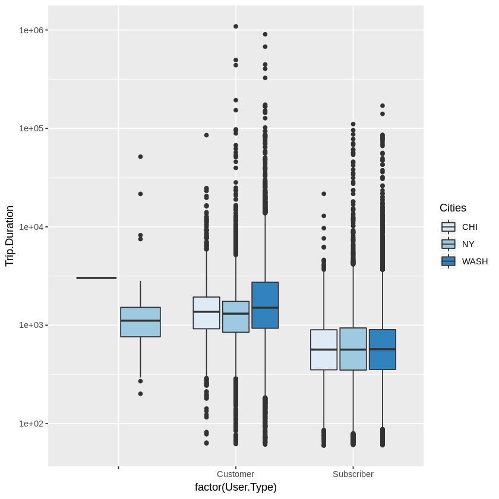

```r
library(ggplot2)
ny['CITY'] = 'NY'
wash['CITY']='WASH'
chi['CITY']='CHI'
common_cols <- intersect(colnames(ny), colnames(wash))
df = rbind(subset(ny, select = common_cols), subset(wash, select = common_cols))
common_cols <- intersect(colnames(df), colnames(chi))
df = rbind(subset(df, select = common_cols), subset(chi, select = common_cols))

ggplot(aes(x = factor(User.Type), y = Trip.Duration), data = df) +
           geom_boxplot(aes(fill = CITY)) +
           scale_fill_brewer(type ='seq', guide = guide_legend(title='Cities')) +
           scale_y_log10()
```

```r
'''
                                                        References
"Add Legend to Geom-Line-Graph in R" (n.d.). Stack OVerflow. Retrieved May 14, 2021 from https://stackoverflow.com/questions/40833809/add-legend-to-geom-line-graph-in-r
"Better Bar Graph" (2021, May 14). Udacity. Retrieved May 18, 2021 from https://knowledge.udacity.com/questions/584232
"Descriptive Statistics" (n.d.). Stat Methods. Retrieved May 14, 2021 from https://www.statmethods.net/stats/descriptives.html#:~:text=R%20provides%20a%20wide%20range,with%20a%20specified%20summary%20statistic.&text=Possible%20functions%20used%20in%20sapply,median%2C%20range%2C%20and%20quantile
"How do I find the total travel time for subscribers and customers?"(2021, June 2). Udacity. Retrieved June 4, 2021 from https://knowledge.udacity.com/questions/602549
"How to Install R Packages that are not in R-Essential" (n.d.). Stack Overflow. Retrieved May 14, 2021 from https://stackoverflow.com/questions/34705917/how-to-install-r-packages-that-are-not-available-in-r-essentials
"Using a For Loop to Append to an Empty Object in R" (n.d.). Stack Overflow. Retrieved May 18, 2021 from https://stackoverflow.com/questions/25233574/usings-a-for-loop-to-append-to-an-empty-object-in-r
"NA Remove" (n.d.). Udacity. Retrieved May 12, 2021 from https://knowledge.udacity.com/questions/290200
"Need help on plotting the correct graph. I did this separately for all the 3 cities" (n.d.). Udacity. Retrieved May 12, 2021 from https://knowledge.udacity.com/questions/106081
"Why is fun.y ignored for geom_line?" (2021, May 25). Udacity. Retrieved June 2, 2021 from https://knowledge.udacity.com/questions/595768



'''
```

[output not shown]

**I got the total travel time for all users in each city and graphed the results. For subscibers, the medians for all three cities are about the same. For Customers, the medians vary.**

## Finishing Up

> Congratulations! You have reached the end of the Explore Bikeshare Data Project. You should be very proud of all you have accomplished!

> **Tip**: Once you are satisfied with your work here, check over your report to make sure that it is satisfies all the areas of the [rubric](https://review.udacity.com/#!/rubrics/2508/view).

## Directions to Submit

> Before you submit your project, you need to create a .html or .pdf version of this notebook in the workspace here. To do that, run the code cell below. If it worked correctly, you should get a return code of 0, and you should see the generated .html file in the workspace directory (click on the orange Jupyter icon in the upper left).

> Alternatively, you can download this report as .html via the **File** > **Download as** submenu, and then manually upload it into the workspace directory by clicking on the orange Jupyter icon in the upper left, then using the Upload button.

> Once you've done this, you can submit your project by clicking on the "Submit Project" button in the lower right here. This will create and submit a zip file with this .ipynb doc and the .html or .pdf version you created. Congratulations!

```r
system('python -m nbconvert Explore_bikeshare_data.ipynb')
```